# Prediction Model For Weight Lifting Manner

Tracy

October 21, 2015

# **1. Executive Summary**

The aim of this project to to predict the manner(classe A,B,C,D,E) in which the 6 healthy young men did their unilateral dumbbell bicep curl exercise.The report used the data collected from accelerometers on the belt, forearm, arm, and dumbell. A model is then built using PCA preProcessing method to narrow down variables and random forest method (with its own cross validation) to predict results. The model got 97.59% accuracy and out of sample error rate of 2.41%. The out of sample error rate comes from the overall out of sample error rate outside of the training data.

# **2. Reading and Cleansing the Data**

Frist, let’s look into the data by loading both training and testing data in and used summary(training) and summary(testing). We found that training data has 160 variables and 19622 observations with significant number of missing value or zero value variabels. Affter observation, these missing values add up to 19k+ for every single variable that’s affected. **Since these variables are calcultated rather than the objectively measured data and huge number of missing values tend to affect the model training in a great extent.Therefore We eliminate them and truncate the variable list down to 60 to get a new training set** *training0*. Same applied to the testing data and we have a new set called *testing0*(60 variables).

# **3. Establishing the Prediction Model**

To predict, we follow this logic chain to proceed: **question -> input data -> features -> algorithm -> parameters -> evaluation**. In our case, **the question is “to predict the manner(classe variale in the data set) in which they did the exercise.”**

**Step1: To input data**,since we’ve already read and cleansed the data. Here by inputing data, we mean split the data into 70% training set and 30% testing set using createDataPartition (){caret} function. The new traing data is called *train* and the new testing data is called *test*. The testing data we originally loaded becomes a validation dataset.

**Step2: To extract the features**, we **first explore the data** by looking at the density of the outcome variable (**chart1**) and the featurePlot of different variables(**char2**). However,it’s difficult to have an overarching picture of how the data looks due to the huge number of predictors. **Second, we need to know what would be considered as good features.** According to the lecture, good features are 1).lead to data compression;2).retain relevant information;3).are created based on expert application knowledge. We know the studied data is about accelerometer sensor measurement. **Therefore, any variables related to sensing specifics are relevant and necessary such as gyroscope, acceleration, magnet variables.**Since there are A,B,C,D different styles of doing unilateral dumbbell bicep curls which differ in arm, hip and dumbbell positions, any variables related to that is necessary and should be retained. In our case, “roll”,“pitch”,“yaw” related variables need to be kept. **However, are they equally important for model predicting?** we know from the lecture that the more complicated the model is, the less scalable it is. It will potentially lead to overfitting as when we are capturing signal, we also capture noise. **Therefore, we will use a preprocessing method “Primary Component Analysis(PCA)”** to find the weighted combination of predictors and capture the most inforamtion possible. We set the threshold of PCA variance to be 95% which required 25 components.Therefore,we got a new dataset *train1* with only 26 variables (including the outcome variable ‘classe’) and *test1*(26 variables too) to be the new testing set within the big training data.

**Step3: To develop an algorithm using random forest**, we built a model with random Forest function and then predict with this model fit.{caret} package itself has a random forest method called “rf” which takes above an hour to train the data. Therefore, we opted in using {randomForest} package which takes only a few minutes. **The randomForest by default uses cross validation as well**.Each tree is built using samples from the original data we pass to randomForest. Due to this sampling, each tree will leave out some rows (36.8% default). These rows are called out-of-bag samples. After each tree is built, the out-of-bag samples are run through the forest. After running the model, we created 500 trees and tried 5 random variables at each split. In addition, we found the out of bag estimate error rate is 2.5%.

Using this model, we predict the *classe outcome* for the test1 data(30% of training data) and had 97.59% of accuracy.

**Step4: To evaluate the result**, using confusionMatrix function, **we found 97.59% overll model accuracy and 2.41% out of sample error rate (1-accuracy)**. The model itself gave OOB(out of bag) estimate of error rate of 2.5% which is well aligned with the overall out of sample error rate. The lecture specifies that the out of sample error rate is the error occured outside of the training dataset while the OOB error rate are from out-of-bag samples which are left out rows at each tree during training. Therefore, we go by with the overall out of sample error rate as it seems to fit the out of sample concept better.

***Caveat of using RandomForest** Random forest is one of the top performing models in machine learning with very high accuracy. However, the downside is it will overfit a model.The reason is that a randomForest fittd model is normally complex, having many parameters relative to the number of observations. It is expected that the fitted relationship will appear to perform less well on a new data set than on the data set we used for fitting. Therefore, it’s normally suggested to use some techniques to avoid overfitting.

# **4. Predicting “New” Data and Submitting the Answer**

Using the same PCA scheme to preprocess the testing data we originally loaded, we got 20 predictions and write them with the given write.table function to generate 20 txt file in the working directory.Submitting the answers, we got 20 out of 20 predictions correctly.

# **5.Appendix**

Part1: not shown,only used to generate the charts; Part 2: show all the code used in the project.

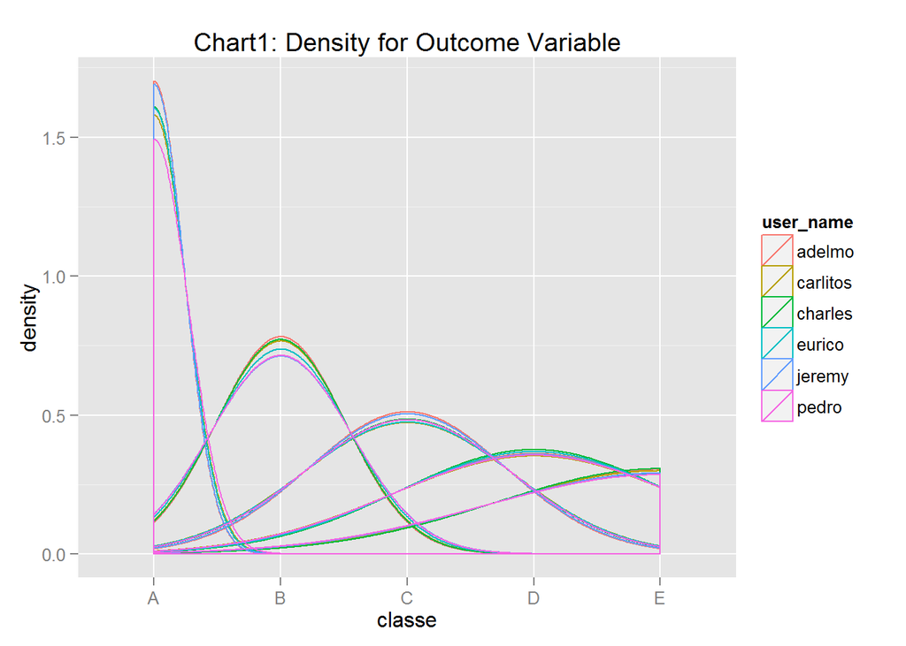

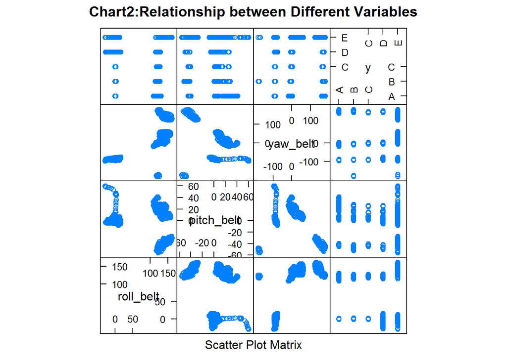

Chart3: Accuracy and Out of Sample Error Rate

|  | Accuracy | Out of Sample Error=1-Accuracy | P value | OOB Error Rate |
| --- | --- | --- | --- | --- |
| Value | 0.9759 | 0.0241 | < 2.2e-16 | 2.5% |

```r
#PART 2: All the code

#cleansing the data

library(caret);library(ggplot2);library(dplyr)
training <- read.csv("./pml-training.csv", na.strings="NA",stringsAsFactors=FALSE)
testing <- read.csv("./pml-testing.csv", na.strings="NA",stringsAsFactors=FALSE)


training0=training[,!apply(training,2,function(x) any(is.na(x)))]
training0=select(training0,-starts_with("kurtosis"))
training0=select(training0,-starts_with("skewness"))
training0=select(training0,-starts_with("max"))
training0=select(training0,-starts_with("min"))
training0=select(training0,-starts_with("amplitude"))
str(training0)

#same applied to testing data
testing0=testing[,!apply(testing,2,function(x) any(is.na(x)))]



#splitting the data into 70% training and 30% testing data
intrain=createDataPartition(y=training0$classe,p=0.7,list=FALSE)
train=training0[intrain,]
test=training0[-intrain,]
str(train)
#need to print code and the charts
qplot(classe,colour=user_name,data=train,geom="density",main = "Chart1: Density for Outcome Variable")

library(Hmisc)
featurePlot(x=train[,c("roll_belt","pitch_belt","yaw_belt")],
            y = train$classe,
            plot="pairs",,main="Chart2: Relationship between Different Variables")

#since pca only applies to numeric variables, the non-numeric variables have been excluded as they are not related variables anyway.
proc=preProcess(train[,-c(1:7,60)], method="pca",thresh = 0.95,pcaComp = 25)
train0=predict(proc,newdata=train[,-c(1:7,60)])
train1=cbind(train0,train[,60])
names(train1)[26]="classe"

test0=predict(proc,newdata=test[,-c(1:7,60)])
test1=cbind(test0,test[,60])
names(test1)[26]="classe"

#using randomForest to fit the model and predict within the 30% of the starting training data.
library(randomForest)
set.seed(1235)
modfit=randomForest(classe~.,data=train1)
pred=predict(modfit,newdata=test1)
#accuracy calculation before confusion matrix:
acu=mean(pred==test1$classe)

#error rate=1-accuracy
er=1-acu

confusionMatrix(test$classe,pred)

df=matrix(c("0.9759","0.0241","< 2.2e-16","2.5%"),ncol = 4,nrow = 1,byrow = TRUE,dimnames = list("Value",c("Accuracy","Out of Sample Error=1-Accuracy","P value","OOB Error Rate")))

knitr::kable(df,caption = "Chart3: Accuracy and Out of Sample Error Rate")

# predict on the validation data
testing1=predict(proc,newdata=testing0[,-c(1:7,60)])
testing2=cbind(testing1,testing0[,60])
names(testing2)[26]="classe"
pred1=predict(modfit,newdata=testing2)

#wring the answers into txt file
pml_write_files = function(x){
  n = length(x)
  for(i in 1:n){
    filename = paste0("problem_id_",i,".txt")
    write.table(x[i],file=filename,quote=FALSE,row.names=FALSE,col.names=FALSE)
  }
}
answers <- as.character(pred1)
pml_write_files(answers)
```